# Group 19

## Andre Gnandt and Ilakiya Yuvarani Paulraj

# DATA 550 - Lab 2 - EDA on movie data

In this lab we will be using both R and Python, and for each question you will develop an answer both in `ggplot` and in `Altair`. Although the `%%R` cell magic makes it convenient for us to do this in the same notebook, I would still recommend that you use a separate Jupyter Notebook with a dedicated R kernel or RStudio to develop your R code. The reasons for this are that autocompletion works better there and the error messages are easier to understand. Once you have developed the code for a question you can paste it into the corresponding R cell here and make sure it runs and shows up in the exported HTML.

If your `rpy2` does not work, you can paste in entire cells from an R-kernel including the output plots, or you can submit a different notebook on GitHub for the R part, but you must write this in the canvas comments or next to your repo link in this notebook so that the TAs know when they grade.

## Submission instructions

rubric={mechanics:2}

You receive marks for submitting your lab correctly, please follow these instructions:

- Create a GitHub Repo for your group.
  - Keep this organized, i.e. with a separate clearly marked folder for each assignment.
- [Click here to view a description of the rubrics used to grade the questions](https://github.com/UBC-MDS/public/tree/master/rubric)
- Push your `.ipynb` file to your GitHub repository for this lab.
- Include a clickable link to your GitHub repo for the lab just below this cell
  - It should look something like this https://github.ubc.ca/folder_path/DATA_550_labX_groupY.
- Upload a `.html` version of your assignment to Canvas.
  - Run all cells in your notebook to make sure there are no errors by doing `Kernel -> Restart Kernel and Run All Cells...`
  - Convert your notebook to .html format using `File -> Save and Export Notebook As -> HTML`
  - Submit and double check that your have submitted the correct file to Canvas

### GITHUB REPO: https://github.com/andre-gnandt/DATA-550-Lab-Group-19

```python
# Run this cell to ensure that altair plots show up in the exported HTML
# and that the R cell magic works
import altair as alt
import warnings
warnings.filterwarnings("ignore", category=FutureWarning)
# Save a vega-lite spec and a PNG blob for each plot in the notebook
alt.renderers.enable('mimetype')
# Handle large data sets without embedding them in the notebook
#alt.data_transformers.enable('data_server')
alt.data_transformers.enable("vegafusion")

# Load the R cell magic
%load_ext rpy2.ipython
```

```
Error importing in API mode: ImportError('On Windows, cffi mode "ANY" is only "ABI".')
Trying to import in ABI mode.
```

# 0. Get motivated!

I have heard that the movie market is a lucrative business, and have been looking into starting my own online streaming service together with a few friends. Before we do this, we need to understand the movie market better so that we can get a competitive edge over existing service. I have been looking all over for an aspiring data wrangler and future VIZARD, but haven't been able to track one down. This is where you come in!

[figure not shown]

Together, we must understand the current movie market, which companies produces what kind of movies, and which receive good scores. Then we can have the best movies on our platform and show only those, easy right? I mean...we will show only good movies, I can't believe no one has thought of this before! I have already identified a unique name for this service: Bestflix™.

Don't worry, we're in this together and I will be helping you with the wrangling throughout most exercises if you take charge of the viz part, deal?. Also, I have never failed to start a company before, so you're in good hands. I can already smell the `$$$`, so let's get started!

In this notebook, we will focus on Exploratory Data Analysis (EDA), both for single numerical columns, pairwise numerical columns, numerical columns conditioned on categorical columns and combinations of categorical columns.

# 1. Single numerical columns

### Question 1.1

rubric={reasoning:1,accuracy:1}

#### Python

In the beginning of EDA, it can be good to look at some textual summaries, just to get an idea of what to plot. Download the file `lab2-movies.json` from the course GitHub to your computer, and then read it in using pandas. Using dataframe methods, do the following in three different cells:

1. Display the first few and last few rows of the data.
2. Display info about all columns, data types, and number of NaN values.
3. Display a summary description of the data frame's numerical columns.

```python
# YOUR ANSWER GOES HERE
import pandas as pd

data = pd.read_json("lab2-movies.json")

display(data.head())

display(data.tail())
```

|  | id | title | runtime | budget | revenue | vote_average | vote_count | genres | studios |
| --- | --- | --- | --- | --- | --- | --- | --- | --- | --- |
| 0 | 12 | Finding Nemo | 100 | 94000000 | 940335536 | 3.86 | 33887 | [Animation] | [Pixar Animation Studios] |
| 1 | 13 | Forrest Gump | 142 | 55000000 | 677945399 | 4.05 | 91921 | [Romance, Comedy, Drama] | [Paramount Pictures] |
| 2 | 14 | American Beauty | 122 | 15000000 | 356296601 | 4.13 | 57879 | [Drama] | [DreamWorks SKG] |
| 3 | 16 | Dancer in the Dark | 140 | 12800000 | 40031879 | 3.84 | 4571 | [Drama] | [Canal+] |
| 4 | 22 | Pirates of the Caribbean: The Curse of the Bla... | 143 | 140000000 | 655011224 | 3.81 | 36337 | [Action] | [Walt Disney Pictures] |

|  | id | title | runtime | budget | revenue | vote_average | vote_count | genres | studios |
| --- | --- | --- | --- | --- | --- | --- | --- | --- | --- |
| 1003 | 376290 | Miss Sloane | 132 | 13000000 | 3500605 | 3.63 | 89 | [Drama] | [Canal+] |
| 1004 | 384682 | Office Christmas Party | 105 | 45000000 | 114501299 | 3.00 | 124 | [Comedy] | [DreamWorks SKG, Paramount Pictures] |
| 1005 | 393457 | Fences | 139 | 24000000 | 64414761 | 3.50 | 262 | [Drama] | [Paramount Pictures] |
| 1006 | 393519 | Raw | 99 | 3500000 | 4100000 | 3.48 | 74 | [Horror, Drama] | [Canal+] |
| 1007 | 417644 | CHiPS | 100 | 25000000 | 26800152 | 2.68 | 51 | [Action, Comedy] | [Warner Bros.] |

```python
# YOUR ANSWER GOES HERE
display(data.info())

display(data.isna().sum())
```

```
<class 'pandas.core.frame.DataFrame'>
Index: 1008 entries, 0 to 1007
Data columns (total 9 columns):
 #   Column        Non-Null Count  Dtype
---  ------        --------------  -----
 0   id            1008 non-null   int64
 1   title         1008 non-null   object
 2   runtime       1008 non-null   int64
 3   budget        1008 non-null   int64
 4   revenue       1008 non-null   int64
 5   vote_average  1008 non-null   float64
 6   vote_count    1008 non-null   int64
 7   genres        1008 non-null   object
 8   studios       1008 non-null   object
dtypes: float64(1), int64(5), object(3)
memory usage: 78.8+ KB
```

```
None
```

```
id              0
title           0
runtime         0
budget          0
revenue         0
vote_average    0
vote_count      0
genres          0
studios         0
dtype: int64
```

```python
# YOUR ANSWER GOES HERE
display(data.describe())
```

|  | id | runtime | budget | revenue | vote_average | vote_count |
| --- | --- | --- | --- | --- | --- | --- |
| count | 1008.000000 | 1008.000000 | 1.008000e+03 | 1.008000e+03 | 1008.000000 | 1008.000000 |
| mean | 49888.699405 | 112.183532 | 5.940012e+07 | 1.878759e+08 | 3.240198 | 6907.056548 |
| std | 88325.959056 | 21.527725 | 5.525947e+07 | 2.449621e+08 | 0.471919 | 10794.341581 |
| min | 12.000000 | 63.000000 | 5.000000e+00 | 8.500000e+01 | 1.610000 | 11.000000 |
| 25% | 3627.000000 | 96.000000 | 2.000000e+07 | 4.127994e+07 | 2.947500 | 857.000000 |
| 50% | 10432.500000 | 108.000000 | 4.000000e+07 | 1.018510e+08 | 3.265000 | 2688.000000 |
| 75% | 44658.750000 | 125.000000 | 8.000000e+07 | 2.270864e+08 | 3.590000 | 8774.000000 |
| max | 417644.000000 | 202.000000 | 3.800000e+08 | 2.787965e+09 | 4.430000 | 91921.000000 |

### Question 1.2

rubric={reasoning:1,accuracy:1}

#### R

In the beginning of EDA, it can be good to look at some textual summaries, just to get an idea of what to plot. Download the file `lab2-movies.json` from the course GitHub to your computer, and then run the code for reading in the data that I have provided below. Then do the following in three different cells:

1. Display the first few rows of the data.
2. Display info about all columns, including their data types.
3. Display a summary description of the data frame's numerical columns only.

```python
%%R
library(rjson)
library(tidyverse)
movies <- fromJSON(file = 'lab2-movies.json') %>%
    as_tibble() %>%
    unnest(-c(studios, genres))

head(movies)
# YOUR ANSWER GOES HERE
```

```
# A tibble: 6 x 9
     id title      runtime budget revenue vote_average vote_count genres studios
  <dbl> <chr>        <dbl>  <dbl>   <dbl>        <dbl>      <dbl> <name> <named>
1    12 Finding N~     100 9.40e7  9.40e8         3.86      33887 <chr>  <chr>
2    13 Forrest G~     142 5.50e7  6.78e8         4.05      91921 <chr>  <chr>
3    14 American ~     122 1.5 e7  3.56e8         4.13      57879 <chr>  <chr>
4    16 Dancer in~     140 1.28e7  4.00e7         3.84       4571 <chr>  <chr>
5    22 Pirates o~     143 1.4 e8  6.55e8         3.81      36337 <chr>  <chr>
6    58 Pirates o~     151 2   e8  1.07e9         3.47      15079 <chr>  <chr>
```

```
In addition: Warning messages:
1: package 'rjson' was built under R version 4.5.2
2: package 'ggplot2' was built under R version 4.5.2
```

```python
%%R

glimpse(movies)
# YOUR ANSWER GOES HERE
```

```
Rows: 1,008
Columns: 9
$ id           <dbl> 12, 13, 14, 16, 22, 58, 59, 70, 73, 74, 76, 78, 85, 87, 8~
$ title        <chr> "Finding Nemo", "Forrest Gump", "American Beauty", "Dance~
$ runtime      <dbl> 100, 142, 122, 140, 143, 151, 96, 132, 119, 116, 105, 117~
$ budget       <dbl> 9.40e+07, 5.50e+07, 1.50e+07, 1.28e+07, 1.40e+08, 2.00e+0~
$ revenue      <dbl> 940335536, 677945399, 356296601, 40031879, 655011224, 106~
$ vote_average <dbl> 3.86, 4.05, 4.13, 3.84, 3.81, 3.47, 3.63, 3.84, 4.15, 3.1~
$ vote_count   <dbl> 33887, 91921, 57879, 4571, 36337, 15079, 5082, 13901, 318~
$ genres       <named list> "Animation", <"Romance", "Comedy", "Drama">, "Dram~
$ studios      <named list> "Pixar Animation Studios", "Paramount Pictures", "~
```

```python
%%R
summary(Filter(is.numeric, movies))

# YOUR ANSWER GOES HERE
```

```
       id            runtime          budget            revenue
 Min.   :    12   Min.   : 63.0   Min.   :5.00e+00   Min.   :8.500e+01
 1st Qu.:  3627   1st Qu.: 96.0   1st Qu.:2.00e+07   1st Qu.:4.128e+07
 Median : 10432   Median :108.0   Median :4.00e+07   Median :1.019e+08
 Mean   : 49889   Mean   :112.2   Mean   :5.94e+07   Mean   :1.879e+08
 3rd Qu.: 44659   3rd Qu.:125.0   3rd Qu.:8.00e+07   3rd Qu.:2.271e+08
 Max.   :417644   Max.   :202.0   Max.   :3.80e+08   Max.   :2.788e+09
  vote_average     vote_count
 Min.   :1.610   Min.   :   11
 1st Qu.:2.947   1st Qu.:  857
 Median :3.265   Median : 2688
 Mean   :3.240   Mean   : 6907
 3rd Qu.:3.590   3rd Qu.: 8774
 Max.   :4.430   Max.   :91921
```

```python
%%R
movies %>%
  select(where(is.numeric)) %>%
  glimpse()
```

```
Rows: 1,008
Columns: 6
$ id           <dbl> 12, 13, 14, 16, 22, 58, 59, 70, 73, 74, 76, 78, 85, 87, 8~
$ runtime      <dbl> 100, 142, 122, 140, 143, 151, 96, 132, 119, 116, 105, 117~
$ budget       <dbl> 9.40e+07, 5.50e+07, 1.50e+07, 1.28e+07, 1.40e+08, 2.00e+0~
$ revenue      <dbl> 940335536, 677945399, 356296601, 40031879, 655011224, 106~
$ vote_average <dbl> 3.86, 4.05, 4.13, 3.84, 3.81, 3.47, 3.63, 3.84, 4.15, 3.1~
$ vote_count   <dbl> 33887, 91921, 57879, 4571, 36337, 15079, 5082, 13901, 318~
```

### Question 1.3

rubric={viz:1,accuracy:1}

#### Python

Create a single histogram of a numerical column of your choice, choosing an appropriate number of bins and set the figure height to 100.

```python
# YOUR ANSWER GOES HERE
alt.renderers.enable('default')
alt.Chart(data).mark_bar().encode(
    x=alt.X('vote_count',type = "quantitative", bin=alt.Bin(maxbins=20)),
    y='count()').properties( height =  100)
```

[interactive chart not shown]

### Question 1.4

rubric={viz:1,accuracy:1,reasoning:1}

#### R

1. Create a single density estimate of a numerical column of your choice by using he density geom.
2. Try setting the `alpha` parameter to a float between 0 and 1 and the `fill` parameter to a color name as a string to get a shaded density, which I find visually appealing =) Set these inside the geom, not inside the aes function.
3. Do you think either of this density plot or the histogram in the previous exercise gives you a better understanding of the underlying data? Which one and why?

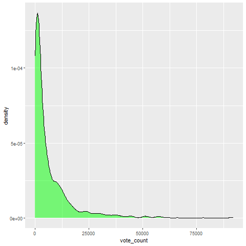

```python
%%R
# YOUR ANSWER GOES HERE
ggplot(data=movies, aes(x = vote_count))+geom_density(alpha = 0.5, fill = "green")
```

I think the density plot gives me a better understanding of the underlying data, because it is continuous and is easier to interpret frequencies across all values of the vote count, rather than just count distributions at specific bin intervals.

### Question 1.5

rubric={viz:2,accuracy:2}

#### Python

```python
# YOUR ANSWER GOES HERE
n = data.select_dtypes(include="number").columns.drop("id").tolist()
n = n[:6]


hist = alt.Chart(data).mark_bar().encode(
    x=alt.X(alt.repeat("repeat"), bin=alt.Bin(maxbins=20)),
    y=alt.Y("count()")).properties(height=100).repeat(repeat=n, columns=2)

hist
```

[interactive chart not shown]

### Question 1.6

rubric={viz:2,accuracy:2}

#### R

- Pipe the data fame's numerical columns (except `id`) into ggplot (the `.select_if()` method can help here, or you can do it manually).
- Copy the code from your density plot above and paste it here. Modify the code so that it accepts the piped dataframe and plots one density estimate per column in a plot grid with 2 columns and 3 rows. Don’t use a loop, use pivoting and faceting instead (example in the lecture videos).

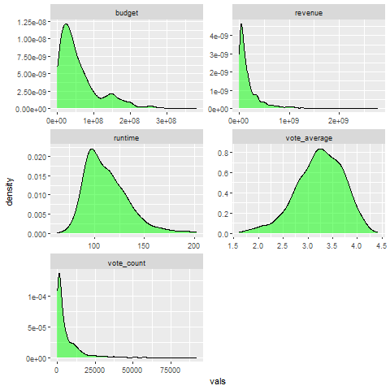

```python
%%R

movies %>%
    select_if(is.numeric) %>%
    select(-id) %>%
    pivot_longer(
        cols = everything(),
        names_to = "var",
        values_to = "vals"
    ) %>%
ggplot(aes(x=vals))+geom_density(alpha=0.5, fill="green")+facet_wrap(~var, ncol = 2,  scales = "free")

# YOUR ANSWER GOES HERE
```

# 2. Pairwise numerical columns

### Question 2.1

rubric={viz:2,accuracy:2}

#### Python

Next, let’s look at the relationships between pairs of numerical columns.For this we will create a scatterplot matrix (SPLOM) for all numerical columns except id.

1. I recommend starting with creating a single scatter plot and gradually substituting in the repeating columns.
2. Do not include zero on either axis unless the data actually starts at zero.
3. Reduce each subplots height and width to be able to see the entire lower diagonal in view.
4. Set the opacity and size of the points directly inside `mark_point()` in order for the plots to appear less saturated.
5. Configure the axes to remove or shrink the font of the axes labels (and optional reduce the axes titles' size). Plots don't have to look perfect during EDA, the point here is to pick up trends, not necessarily to read all labels.

You can [study this example if you want guidance.](https://altair-viz.github.io/gallery/scatter_matrix.html)

```python
# YOUR ANSWER GOES HERE
s = alt.Chart(data).mark_point(opacity=0.5, size=20).encode(
    x=alt.X(alt.repeat("column"), type="quantitative",scale=alt.Scale(zero=False)),
    y=alt.Y(alt.repeat("row"), type="quantitative", scale=alt.Scale(zero=False))).properties(width=200, height=200
).repeat(row=n, column=n).configure_axis(labelFontSize=0,   titleFontSize=8  )

s
```

[interactive chart not shown]

### Question 2.2

rubric={viz:1,accuracy:1}

#### R

Oh cra.. I mean: DONT PANIC! Everything is under control... ok let's try the same thing in R Create a scatterplot matrix (SPLOM) of all numerical columns except `id`.

There is nothing built into `ggplot` for this but the `GGally` package has a handy `ggpairs` function for this, which also plots single column densities on the diagonal and correlation coefficients on the upper corner. Install this package an then use the `ggpairs`.

```
In addition: Warning message:
 plot: [5, 5] [=================================================]100% est: 0s
```

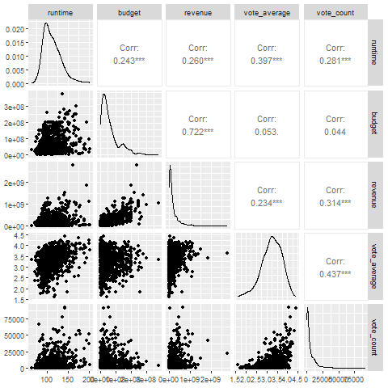

```python
%%R

library(GGally)
library(ggplot2)

ggpairs(
  movies[, c("runtime", "budget", "revenue", "vote_average", "vote_count")]
)

# YOUR ANSWER GOES HERE
```

### Question 2.3 (Optional)

rubric={viz:0.5,accuracy:0.5}

#### Python

Another way of viewing the pairwise relationships between numerical column is to assess their correlation coefficients. It can be a good idea to use spearman instead of pearson correlation in order to pick up nonlinearities, so make sure to use that below.

I have done most of the wrangling, but you need to fill in the one blank and then view the dataframe to figure out how to plot it. Use some type of point plot with a marker of your choice and make an informed decision of which encoding channels to map the different data frame columns to.

```python
# YOUR ANSWER GOES HERE

corr_df = data[n].corr(method = "spearman").stack().reset_index(name='corr')
corr_df.columns = ["var1", "var2", "corr"]

alt.Chart(corr_df).mark_point(shape="square", size=50).encode(
    x=alt.X("var1", type="nominal"),
    y=alt.Y("var2", type="nominal"),
    color=alt.Color("corr", type="quantitative"),
    size=alt.Size("corr", type="quantitative")
)
```

[interactive chart not shown]

### Question 2.4 (Optional)

rubric={accuracy:0.5,reasoning:0.5}

#### R

We're getting close, dont give up! Remember, we're in it for the `$$$`

1. There is nothing built into `ggplot` for correlations but the `GGally` package has a handy `ggcorr` function we can use. You could also calculate it manually and use `geom_tile` if you prefer.
2. Compare this to the plot you made with Altair above. Which visualization do you prefer for viewing the correlation? Briefly explain why in <90 words.

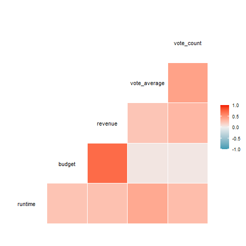

```python
%%R

ggcorr(
  movies[, c("runtime", "budget", "revenue", "vote_average", "vote_count")]
)

# YOUR ANSWER GOES HERE
```

### Question 2

I prefer the plot made in altair because it is easier to find an exact pair of 2 of the numerica columns to analyze their correlations in the grid, rather than in the R ggcorr plot which is a bit harder to interpret at first glance.

### Question 2.5 (Optional)

rubric={viz:0.5,accuracy:0.5}

#### Python

In the lecture, I mentioned hat 2D histograms is a good alternative when you scatter plots become oversaturated. Copy your code from 2.1 and change it so that we can see multiple “heatmap-like” 2D histograms instead of scatter plots.

```python
# YOUR ANSWER GOES HERE
h = alt.Chart(data).mark_rect().encode(
    x=alt.X( alt.repeat("column"),type="quantitative",bin=alt.Bin(maxbins=25),scale=alt.Scale(zero=False)),
    y=alt.Y(alt.repeat("row"),type="quantitative",bin=alt.Bin(maxbins=25), scale=alt.Scale(zero=False)),color=alt.Color("count():Q")
).properties(height=200).repeat(row=n, column=n
).configure_axis(labelFontSize=0, titleFontSize=8)

h
```

[interactive chart not shown]

# 3. EDA of numerical columns conditioned on a categorical column (genres)

### Question 3.1

rubric={viz:1,accuracy:1}

#### Python

Lots of interesting variation in the histograms above! I wonder if some of it can be explained by movie genre or which studio made the film… This could be valuable information for Bestify™ so let’s find out!

We’ll start with the movie genres. If you look at the data frame, you can see that each film has multiple genres in a list. This is not ideal and mean we must make a decision if we are counting the film once per genre or once overall. Since we have no information about which is the main genres, I suggest we go ahead and count it once per genre. In order to do this we need to replicate each row once per genre in the genres column. Luckily there is a pandas method called `explode` for exactly this. I have already done the necessary wrangling here, but please view the df so that you understand what happens and [check out pandas doc for a simpler example](https://pandas.pydata.org/pandas-docs/stable/reference/api/pandas.DataFrame.explode.html).

1. Use this new dataframe and create multiple boxplots inside a single figure by have genres on the y-axis and revenue on the x axis.
2. Boxplots can only be sorted by passing an explicit list of the sort column, in this case the genres. I want you to sort the genres by median revenue, so that the median lines of the box plot are nicely sorted. I have given you a skeleton below where you can fill in the blanks, but you are also free to do it your own way. In the en you need a list that you can pass to `sort` inside `alt.Y()`.

Once you have made the boxplot, you will see some interesting outliers. Remember that you can view what films these are by setting `tooltip='title'`, enjoy exploring!

```python
# Uncomment and run these lines
# boom_genres = movies.explode('genres')
## Sorting by revenue because it is all about the money, money, money...
# genres_by_revenue = boom_genres.______('genres')['revenue'].______().___________().index._______()

# YOUR ANSWER GOES HERE

boom_genres = data.explode('genres')
#Sorting by revenue because it is all about the money, money, money...
genres_by_revenue = boom_genres.groupby('genres')['revenue'].median().sort_values().index.tolist()

# YOUR ANSWER GOES HERE

alt.Chart(boom_genres).mark_boxplot().encode(
    y=alt.Y('genres:N', sort=genres_by_revenue, title='Genre'),
    x=alt.X('revenue:Q', title='Revenue', scale=alt.Scale(zero=False)),
    tooltip=['title:N', 'genres:N', 'revenue:Q']
)
```

[interactive chart not shown]

### Question 3.2

rubric={viz:1,accuracy:2}

#### R

Let's create a explosion in R as well. In the tidyverse, exploding a list / vector from a column is referred to as unnesting it, less action-packed but maybe even more descriptive? =)

I have already done the necessary wrangling here, but please view the df so that you understand what happened and [check out tidyr doc for a simpler example](https://tidyr.tidyverse.org/reference/nest.html).

1. Use this new dataframe and create multiple violinplots inside a single figure by having genres on the y-axis and revenue on the x axis.
2. Read the documentation of the violin plot to find out how you can use its parameters to add a line for the median (hint: the same as quantile 0.5).
3. As we did in the previous lecture with `add_count()`, we need to create a new column for sorting, this time using `mutate()`. I want you to sort the genres by median revenue, so that the median lines of the violin plots are nicely sorted. I have given you a skeleton below where you can fill in the blanks, but you are also free to do it your own way. Then use the same function as previous lectures to sort by this new column.

```
In addition: Warning message:
The `draw_quantiles` argument of `geom_violin()` is deprecated as of ggplot2 4.0.0.
i Please use the `quantiles.linetype` argument instead.
```

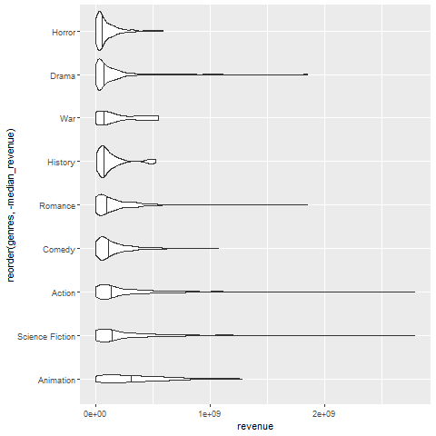

```python
%%R
free_genres <- movies %>% unnest(genres)
free_genres <- free_genres %>%
    group_by(genres) %>%
    mutate(median_revenue = median(revenue, na.rm = TRUE))

ggplot(data = free_genres, aes(x = revenue, y = reorder(genres, -median_revenue))) +
    geom_violin(draw_quantiles = c(0.5))
```

### Question 3.3

rubric={viz:1,accuracy:2,reasoning:2}

#### Python

1. Copy the code from you boxplot above and use the same strategy as for the histograms to repeat this boxplot for all numerical values. Make sure to set the x-axis scale to not include 0 unless necessary, so that the `runtime` boxpot uses the available space well (you don't need to sort the y-axis by different columns, it is better that categories are sorted by median revenue in all facets so that we don't have to keep track of how they move around between subplots).
2. Study the boxplots you just created and reflect over what you see. Identify a research oriented question that you would be interested in exploring and briefly motivate why you think this would be interesting (<90 words, it can be a general question, does not have to relate to Bestflix). This is an open ended question because EDA is often open ended. And even when you go in with one particular hypotheses, you must stay open to what the data tells you and be able to detect interesting relationships that you did not foresee ahead of time.

```python
# YOUR ANSWER GOES HERE
boom_genres = data.explode("genres")

genres_by_revenue = (boom_genres.groupby("genres")["revenue"].median().sort_values().index.tolist())
num = boom_genres.select_dtypes(include="number").columns.drop("id").tolist()

box = alt.Chart(boom_genres).mark_boxplot().encode(
        y=alt.Y("genres:N", sort=genres_by_revenue, title="Genre"),
        x=alt.X(alt.repeat("repeat"), type="quantitative", scale=alt.Scale(zero=False)),
        tooltip=["title:N", "genres:N", 'revenue:Q']).repeat(repeat = num, columns = 2)
box
```

[interactive chart not shown]

### Question 3.4

rubric={viz:1,accuracy:2}

Don't give up soldier, you're almost done with this lab! Bestflix future rests with you.

#### R

1. Copy the code from your violinplot above and use the same faceting strategy as for the histograms to repeat this violinplot for all numerical values (you don't need to sort the y-axis by different columns, it is better that categories are sorted by median revenue in all facets so that we don't have to keep track of how they move around between subplots).
   - In contrast to the histograms you will here need to save the genres and medium_income columns by using the `!` syntax in your call to `pivot_longer`, see the [example in the manual for how to do this](https://tidyr.tidyverse.org/reference/pivot_longer.html).
   - You will also need to define both x and y in your `aes()`, just like in the single violinplot you made above.

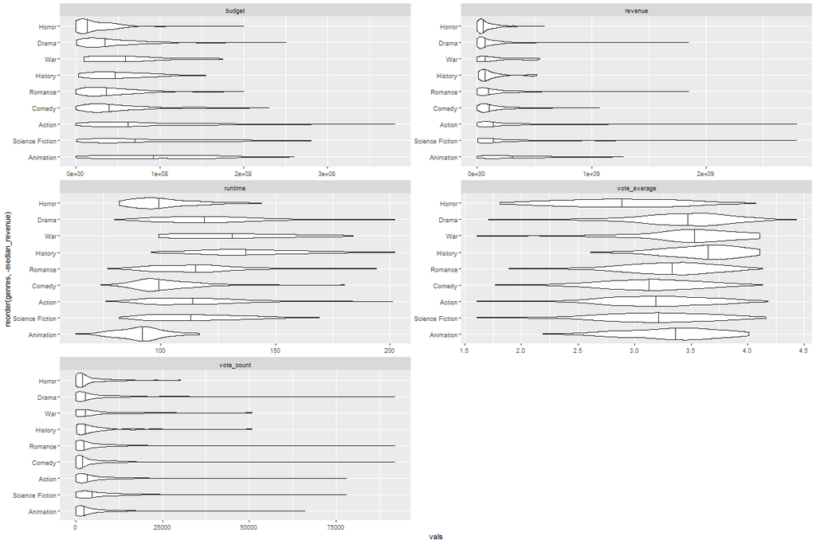

```python
%%R -w 1200 -h 800

free_genres %>%
    select_if(is.numeric) %>%
    select(-id) %>%
    pivot_longer(
        !c(genres, median_revenue),
        names_to = "var",
        values_to = "vals"
    ) %>%
ggplot(aes(x = vals, y = reorder(genres, -median_revenue))) +
    geom_violin(draw_quantiles = c(0.5)) + facet_wrap(~var, ncol = 2, scale = "free")
# YOUR ANSWER HERE
```

### Question 3.5 (Optional)

rubric={viz:0.5,accuracy:0.5}

#### Python

Remember that boxplots hide how many observations there are in each group, so you would need to check this manually. Before coding this answer, glance at your plot above again and reflect for yourself: which do you think is the biggest and smallest category and how many observations does there appear to be in each? Can you tell at all?

Now let’s find out the answers to those questions. Make a barplot with the counts on the x-axis and the genres on the y-axis sorted after count and with the biggest bar closest to the x-axis.

For the most part, we cannot tell at all exactly how many observations are in each genre. We could guess that the boxplots with the greatest range of observations (excluding outliers) may have the most observations (although this is a poor guess), so maybe Science Fiction or Action has the most observations.

```python
# YOUR ANSWER GOES HERE
boom_genres = data.explode("genres")
g_c = ( boom_genres.groupby("genres").size().reset_index(name="count"))

alt.Chart(g_c).mark_bar().encode(x=alt.X("count:Q", title="Count"),
    y=alt.Y("genres:N", sort=alt.SortField(field="count", order="ascending"), title="Genre"),
    tooltip=["genres:N", "count:Q"])
```

[interactive chart not shown]

### Question 3.6 (Optional)

rubric={accuracy:0.5,reasoning:0.5}

#### R

1. Copy over the code from the faceted violinplots above.
2. In contrast to boxplots, violinplots can show an indication of counts by scaling their area based on the number of observations instead of keeping it the same in all violins. Read the violin plot documentation and find the variable that controls the scaling of the area and change it so that the violins indicate the count of the observations.
3. Compare this to the approach we used in Altair for a boxplot + a barplot for counts, which approach do you think is clearer for getting a feeling for the number of observation in each group and why?

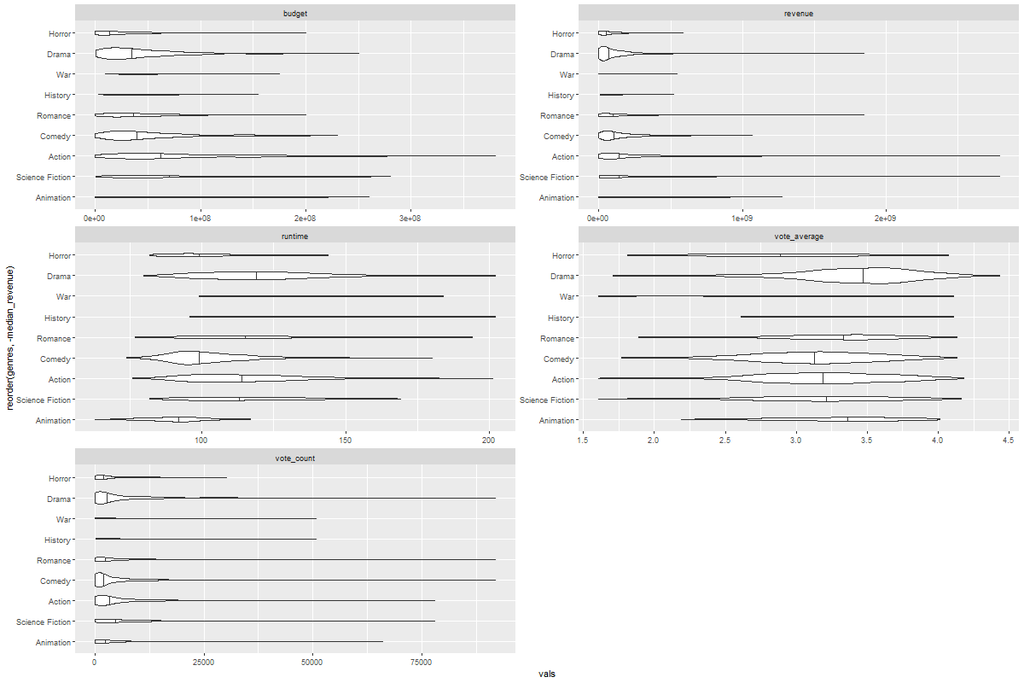

```python
%%R -w 1200 -h 800

free_genres %>%
    select_if(is.numeric) %>%
    select(-id) %>%
    pivot_longer(
        !c(genres, median_revenue),
        names_to = "var",
        values_to = "vals"
    ) %>%
ggplot(aes(x = vals, y = reorder(genres, -median_revenue))) +
    geom_violin(scale = "count", draw_quantiles = c(0.5)) + facet_wrap(~var, ncol = 2, scale = "free")

# YOUR ANSWER GOES HERE
```

### Question 3

I think the violin plot with area set to count is much clearer for getting a feeling for the number of observations in each group instead of the boxplots, because the boxplots don't show any counts, but we can clearly see that the violins with greatest area (like Drama) in the violin plots have greater counts. However, the barplot is the best, because it directly shows us the number of observations of each Genre.

### Question 3.7 (Optional)

rubric={accuracy:0.5,reasoning:0.5}

#### R or Python

Let’s see how the numerical columns vary with different production studios.

1. Create a new dataframe from exploding/unnesting the `studios` column in the `movies` dataframe. You can use my code from above to guide you.
2. Create a similar sorting list as before, but this time with the studies sorted by median revenue.
3. Create the same repeated boxplots for the studios. A tip when you are creating similar plots for two different sections of your notebook, is to use a different color for each so that it is easy to orient yourself (unless you are encoding color as a visual aesthetic of course, but we’re not doing that here). Pick any HTML color either via its hex code or by choosing a name from [this list of named colors](https://stackoverflow.com/a/37232759/2166823). Color all the bars and boxes in this color by setting it inside `mark_boxplot()` / `geom_boxplot()`.
4. Create the same barplot of counts as above for the studios. Color the bars in the same colors as the boxplots.
5. Reflect on the information in the boxplot and / or the barplot. Identify two interesting relationships / questions / discoveries that stand out to you and that you would want to explore further. Briefly motivate why (<90 words).

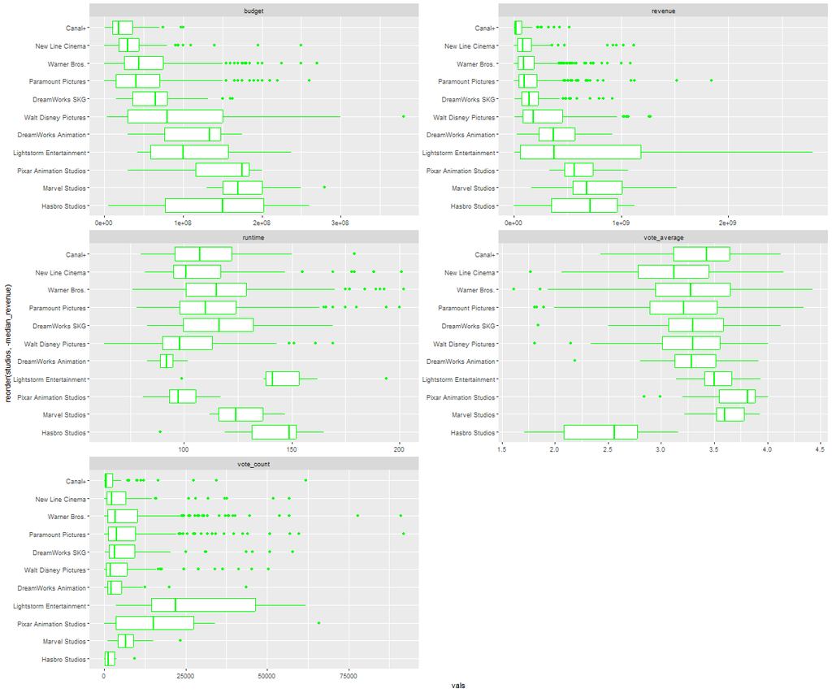

```python
%%R -w 1200 -h 1000
# YOUR ANSWER GOES HERE FOR THE REPEATED BOXPLOT
free_studios <- movies %>% unnest(studios)

free_studios <- free_studios %>%
    group_by(studios) %>%
    mutate(median_revenue = median(revenue, na.rm = TRUE))

free_studios %>%
    select_if(is.numeric) %>%
    select(-id) %>%
    pivot_longer(
        !c(studios, median_revenue),
        names_to = "var",
        values_to = "vals"
    ) %>%
ggplot(aes(x = vals, y = reorder(studios, -median_revenue))) +
    geom_boxplot(color="green") + facet_wrap(~var, ncol = 2, scale = "free")
```

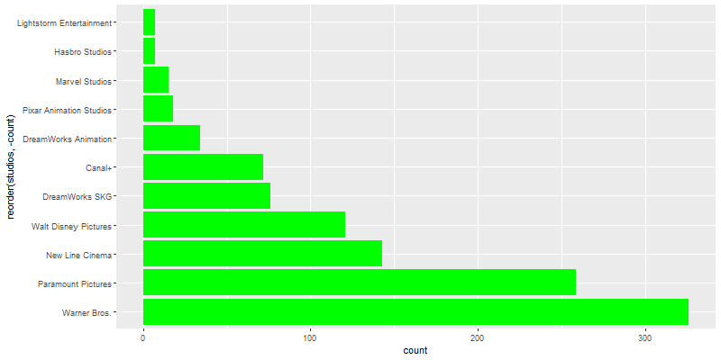

```python
%%R -w 800 -h 400

# YOUR ANSWER GOES HERE FOR THE BAR PLOT OF COUNTS
free_studios <- free_studios %>%
    add_count(studios, name="count")

ggplot(free_studios, aes(y = reorder(studios, -count))) +
    geom_bar(fill = "green")
```

The first question of interest is if there is somewhat of an inverse relationship between median revenue and count of movies produced by the studio (there appears to be one), and why does this trend exist? This is interesting because it seems sort of counter intuitive.

The second question is how strong of a positive relationship between median budget and median revenue of a studios films is there? Is budget the greatest predictor of revenue success for a studio? This is interesting because it could be very useful.